# Data actling Report

### Yes, We All Love Dogs

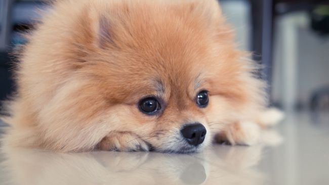

Stock photo of a Pomeranian dog. (Image: © Shutterstock)

### And here are some interesting facts from the tweets about dogs

#### 1. What is the most common breed on twitter?

Golden retriever has 156 tweets from total 1659, which is around 9.4% of tweets.

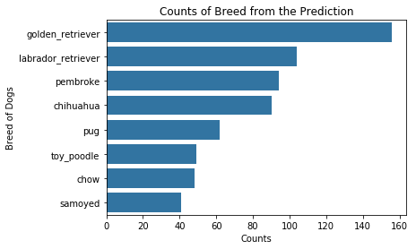

#### Have you ever wondered that among these adorable dogs which breed has the most favorites and retweets?

From all the tweets we have, we add all the favorites and retweets they got by each breeed and calculate the average favorites and retweets each breed got.

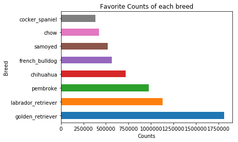

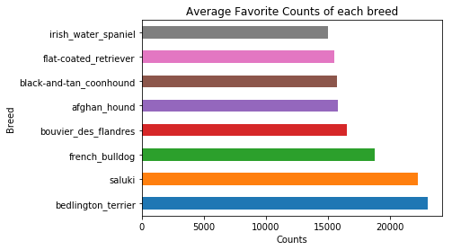

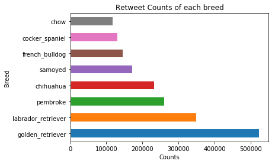

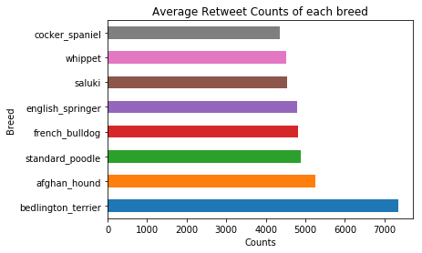

And it turns out that overall favorite and retweet counts still belongs to golden retriever since they have the most tweets. Bedlington terrier has the average favorite and retweet counts, which may caused by fewer tweets. Therefore, I check how many tweets there are for Bedlington terrier, and find out only 6 tweets for bedlington terrier. Compare with 156 tweets for golden retriever, 6 tweets might be too few to make the call which breed has the highest average favorites and retweets.

#### Which breed has the highest rating score?

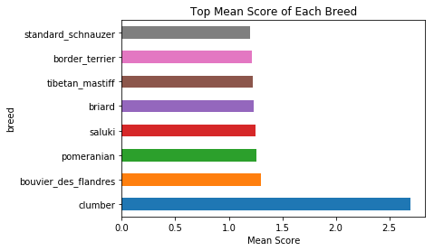

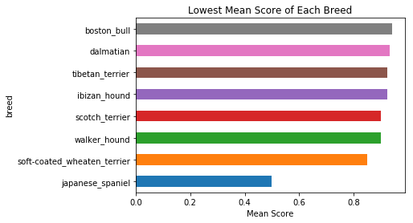

For all the rating score from the tweets, clumber has the highest and japanese_spaniel has the lowest mean score. I check how many tweet it has, since the score of clumber is much higher than the rest, and find out it only has one tweet. This might explain the huge difference of the mean score.

#### Does stage of the dog have influence on the rating score?

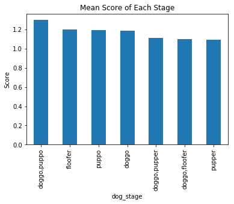

The stage of the dog might also have influence on the score they got. And seems that people on twitter tends to give dogs are in the stage of doggo,puppo higher scores.